# Gas Cost Estimator: estimation of gas costs using the measure marginal method

In this script, there is conducted the estimation for the `measure_marginal` approach for a single given env. The programs is the set of bytecode programs with varying number of opcodes. The measurements are time measurements of program runs or benchmarks. The estimation of each opcode is calculated as the regression against the number of a given opcode in the executed programs.

Parametrization. The evm client name env=erigon, the file with programs programs=pg_marginal_mem.csv, the file with measurements results=results_marginal_mem_erigon.csv,  
the output csv file with estimated cost output_estimated_cost=reports/estimated_cost_erigon_mem.csv, should the details be included in the report details=FALSE.

```r
if (removed_outliers) {
  measurements = remove_compare_outliers(measurements, 'measure_total_time_ns', c(env))
}
```

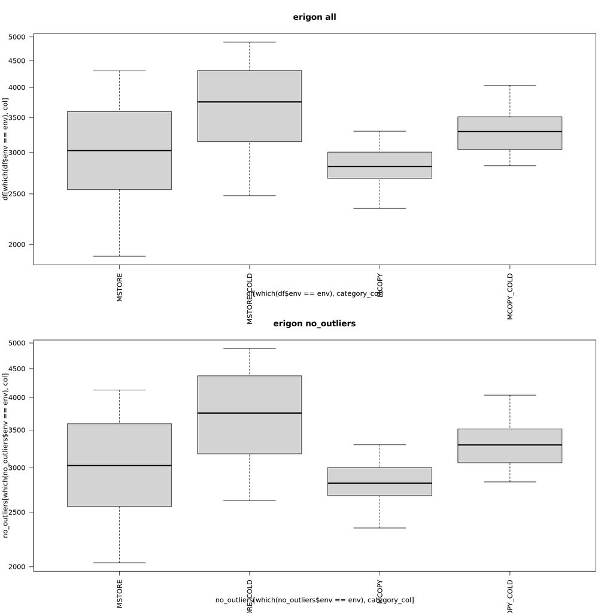

Now we can investigate the linear regressions.

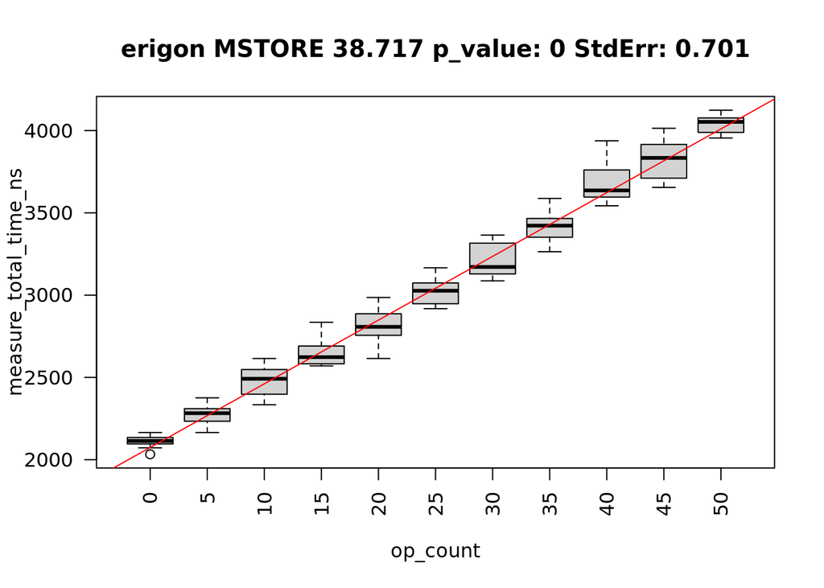

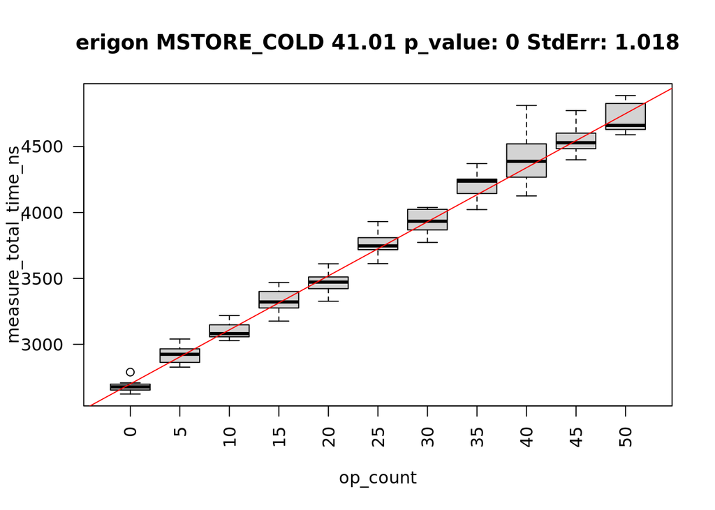

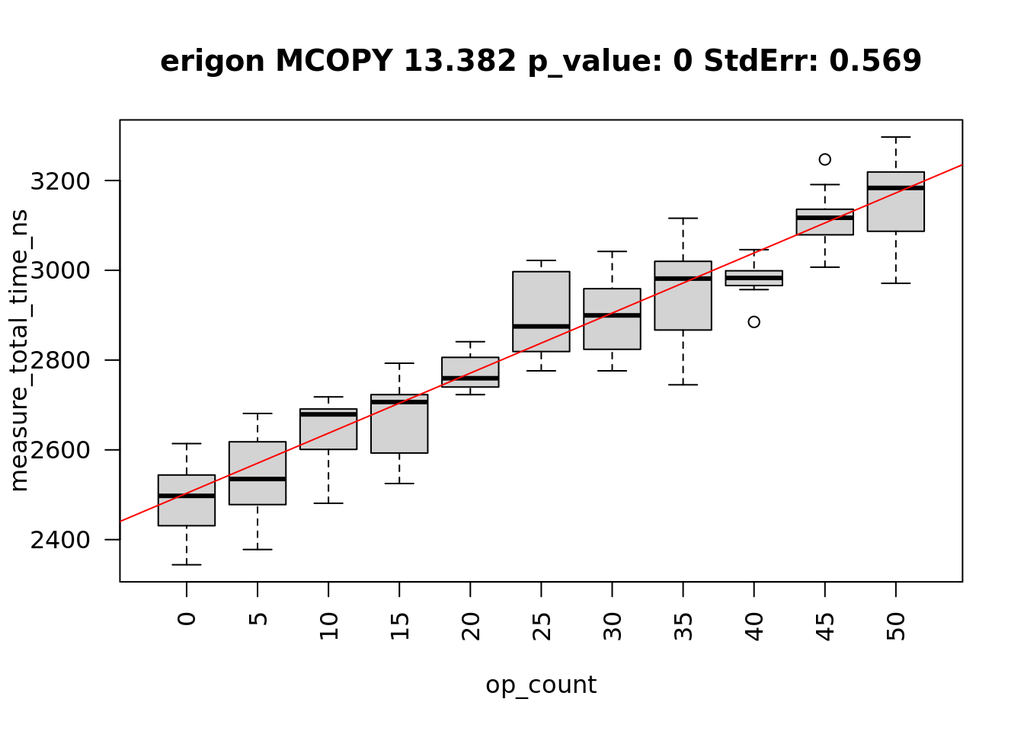

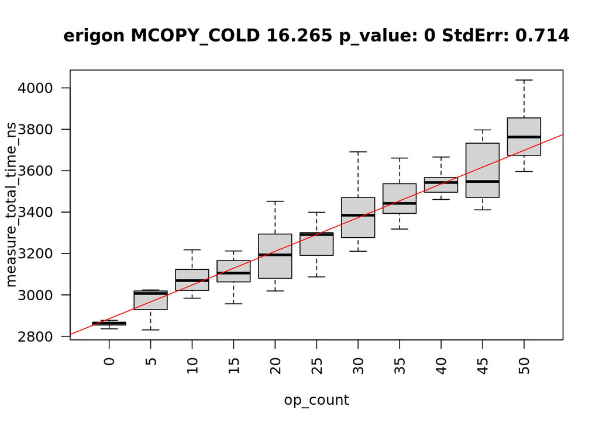

```r
for (opcode in all_opcodes) {
  estimate = compute_all(opcode=opcode, env=env, use_median=TRUE, plots=ifelse(details,'all','scatter'))
  estimates[nrow(estimates) + 1, ] = c(opcode, estimate, env)
}
```

The resulting estimates based on the regressions above.

```r
estimates
```

```
##            op estimate_marginal_ns estimate_marginal_ns_stderr    env
## 1      MSTORE             38.71727                   0.7010198 erigon
## 2 MSTORE_COLD             41.01000                   1.0183441 erigon
## 3       MCOPY             13.38182                   0.5690147 erigon
## 4  MCOPY_COLD             16.26455                   0.7144847 erigon
```

The results are exported to reports/estimated_cost_erigon_mem.csv.